# R for data science - 13 Numbers

Load libraries

```r
library(tidyverse)
library(nycflights23)
```

# 13.2 Making Numbers

**parse**

change data type, e.g. from string to double

`parse_double()` for numbers written as strings

```r
x <- c("1.2", "5.6", "1e3")

parse_double(x)
```

`parse_number()` to ignore everything but numerics

```r
x <- c("$1,234", "USD 3,513", "59%")
parse_number(x)
```

# 13.3 Counts

**count**

great for quick exploration and check during analysis

```r
flights |> count(dest)

# sort = TRUE for high to low
flights |> count(dest, sort = TRUE)

# and what i've been doing a lot was
flights |>
  group_by(dest) |>
  summarize(
    n = n()
  )

# which only starts to be more efficient, when other calculations are of interest
flights |>
  group_by(dest) |>
  summarize(
    n = n(),
    delay = mean(arr_delay, na.rm = TRUE)
  )
```

`n()` works within dplyr verbs, whereas `count()` is directly applicable.

`n_distinct()` for unique/distinct values of variables

```r
# how many different (distinct) carriers are there for each destination (group_by)?
flights |>
  group_by(dest) |>
  summarise(carriers = n_distinct(carrier)) |>
  arrange(desc(carriers))
```

`sum()` adds the values of each row(weighted counts), whereas `count()` oder `n()` give the number of rows

```r
# total miles flewn(sum) by each plane (group_by)
flights |>
  group_by(tailnum) |>
  summarise(miles = sum(distance))

# how often (n) to how many different destinations (n_distinct) went each plane (group_by)
flights |> group_by(tailnum) |>
  summarise(dest = n_distinct(dest), n = n())
```

`wt` as argument of `counr()` can replace `sum()`.

```r
flights |> count(tailnum, wt = distance)
# does the same as
flights |>
  group_by(tailnum) |>
  summarize(mileage = sum(distance))
# without the label though
```

`is.na` as `sum()` argument for counting missing values

```r
# how many flights with no departure time(is.na) - i.e. were cancelled - at each destination(group_by)?
flights |>
  group_by(dest) |>
  summarize(n_cancelled = sum(is.na(dep_time)))
```

## 13.3.1 Exercises

1. How can you use `count()` to count the number of rows with a missing value for a given variable? use with `is.na()` argument

```r
# how many(count) flights had no dep_time(is.na), i.e. were cancelled?
flights |> count(cancelled = is.na(dep_time))
```

2. Expand the following calls to `count()` to instead use `group_by()`, `summarize()`, and `arrange()`:
   1. `flights |> count(dest, sort = TRUE)`

```r
# how many flights(count) for each destination(dest)
flights |> count(dest, sort = TRUE)

# is the same as
flights |>
  group_by(dest) |>
  summarize(n = n()) |>
  arrange(desc(n))
```

2. `flights |> count(tailnum, wt = distance)`

```r
# how many miles (count(wt = distance) hat each plane (tailnum)
flights |>
  count(tailnum, wt = distance)

# is the same as (minus the label)
flights |>
  group_by(tailnum) |>
  summarize(mileage = sum(distance))
```

# 13.4 Numeric transformations

## 13.4.1 Arithmetic and recycling rules

**recycling**

repeating the calculation with the short vector

[output not shown]

```
Generally you only want to recycle single numbers, but R will recycle any shorter length vector.
```

`%in%` just looks up if one of the values in the vector matches, whereas `==` recycles? Let’s test that.

```r
x <- c(1,2,7,99)

7 == x
7 %in% x
```

## 13.4.2 Minimum und Maximum

```r
df <- tribble(
  ~x, ~y, ~z,
  1, 3, 9,
  5, 2, 4,
  7, NA, 12
)

df |>
  mutate(
    min = pmin(x, y, z, na.rm = TRUE),
    max = pmax(x, y, z, na.rm = TRUE)
  )
```

`min` and `max` give the overall max/min and `pmin` and `pmax` give the max/min for each row, in the case of a data frame.

## 13.4.3 Modular arithmetic

`%%` is a function to give the remainder of a division. `%/%` is the function to give the whole number of a division

```r
1:10 %/% 7
1:10 %% 7

# example: get h and min from HHMM time formats
flights |>
  slice_sample(n = 10) |>
  select(dep_time) |>
  mutate( h = dep_time %/% 100,
          min = dep_time %% 100
  )
```

## 13.4.4 Logarithms

Use logarithms to visualize scales better, or make them more accessible for human readout. `log()` compresses and `exp()` stretches out.

```r
1:15
x <- log(1:15)
exp(x)

x <- log2(1:15)
x
2^x
```

## 13.4.5 Rounding

## 13.4.6 Breaks

Basic function for binning vectors into different ranges

```r
x <- -5:5
x
cut(x,
    breaks = -10:10
    )
# same as
cut(x,
    breaks = c(-10, -9, -8, -7, -6, -5, -4, -3, -2, -1, 0, 1, 2, 3, 5, 6, 7, 8, 9, 10))

# see n in bins
table(cut(x,
          breaks = -10:10
          )
      )
```

## 13.4.7 Cumulative and rolling aggregates

```r
x <- 1:10
cumsum(x)
cummean(x)
cumprod(x)
```

## 13.4.8 Exercises

1. Explain in words what each line of the code used to generate Figure 13.1 does.

```r
# choose DF Flights as Data
flights |>
  # groupy by the hour of scheduled departure time (create hour column by dividing the HHMM value of sched_dep_time by 100 and write only whole numbers, basically extract the first two Digits of a four digit number)
  group_by(hour = sched_dep_time %/% 100) |>
  # add the proportion of cancelled flights for each hour(group)
  # cancelled flights are assumed to be "NA" in dep_time
  # calculate the mean of NAs for each group
  summarise(prop_cancelled = mean(is.na(dep_time)),
            n = n()) |>  # and show the total n for each group
  # filter those that should depart after 1 am
  filter(hour > 1) |>
  # create a ggplot with hour of dep (groups) on the x-axis and proportion cancelled on the y-axis
  ggplot(aes(x = hour, y = prop_cancelled)) +
  # display the values as a line with a medium grey
  geom_line(color = "grey50") +
  # add the values as points whose sizes represent the n in each group
  geom_point(aes(size = n))
```

2. What trigonometric functions does R provide? Guess some names and look up the documentation. Do they use degrees or radians?

sin, cos, tan, hypo, adj, opp

I guess degrees, as R usually prioritizes pragmatism.

```r
??trigonometry
```

Well it’s radians, (products of `pi()` as the calculation would be more accurate for an array of arguments, to wait for the calculations with PI till the last possible step.

3. Currently `dep_time` and `sched_dep_time` are convenient to look at, but hard to compute with because they’re not really continuous numbers. You can see the basic problem by running the code below: there’s a gap between each hour.

```r
flights |>
  filter(month == 1, day == 1) |>
  ggplot(aes(x = sched_dep_time, y = dep_delay)) +
  geom_point(na.rm = TRUE)
```

Convert them to a more truthful representation of time (either fractional hours or minutes since midnight).

```r
# Fractional hours
## MM values / 60 = fractional Hours

# take test value
x <- 2359
x %% 100 / 60 + x %/% 100

flights |>
  mutate(sched_dep_frac = (sched_dep_time %% 100 / 60 + sched_dep_time %/% 100)) |>
  ggplot(aes( x = sched_dep_frac, y = dep_delay)) +
    geom_point()
# what are the values beyond 24 ?
flights |>
  mutate(sched_dep_frac = (sched_dep_time %% 100 / 60 + sched_dep_time %/% 100)) |>
  select(sched_dep_time, sched_dep_frac) |>
  arrange(desc(sched_dep_frac))
# forgot a 0 in the formula, corrected

# minutes since midnight
# test calculation
x <- 2359
x %% 100 # minutes
x %/% 100 # hours
x %/% 100 * 60 # hours into minutes
x %% 100 + x %/% 100 * 60 # minutes plus hours into minutes

## whole game
flights |>
  mutate(sched_dep_msm = sched_dep_time %% 100 + sched_dep_time %/% 100 * 60) |>
  ggplot(aes(x = sched_dep_msm, y = dep_delay)) +
  geom_point()
```

4. Round `dep_time` and `arr_time` to the nearest five minutes.

| dep_time | dep_round | arr_time | arr_round |
| --- | --- | --- | --- |
| 1 | 0 | 328 | 330 |
| 18 | 20 | 228 | 230 |
| 31 | 30 | 500 | 500 |
| 33 | 35 | 238 | 240 |
| 36 | 35 | 223 | 225 |
| 503 | 505 | 808 | 810 |
| 520 | 520 | 948 | 950 |
| 524 | 525 | 645 | 645 |
| 537 | 535 | 926 | 925 |
| 547 | 545 | 845 | 845 |

[output cut: 990 more lines]

## 13.5 General Transformations

### 13.5.1 Ranks

| x | row_number(x) | dense_rank(x) | percent_rank(x) | cume_dist(x) | min_rank(x) |
| --- | --- | --- | --- | --- | --- |
| 1 | 1 | 1 | 0.00 | 0.2 | 1 |
| 2 | 2 | 2 | 0.25 | 0.6 | 2 |
| 2 | 3 | 2 | 0.25 | 0.6 | 2 |
| 3 | 4 | 3 | 0.75 | 0.8 | 4 |
| 5 | 5 | 4 | 1.00 | 1.0 | 5 |
| NA | NA | NA | NA | NA | NA |

### 13.5.2 Offsets

something about shifting the data input a certain amount to it’s original positions. Use for, wenn shiftig, or internal comparisons.

### 13.5.3 Consecutive identifiers

For grouping whenever a specified change appears

| time | dif | has_gap | event |
| --- | --- | --- | --- |
| 0 | 0 | FALSE | 0 |
| 1 | 1 | FALSE | 0 |
| 2 | 1 | FALSE | 0 |
| 3 | 1 | FALSE | 0 |
| 5 | 2 | FALSE | 0 |
| 10 | 5 | TRUE | 1 |
| 12 | 2 | FALSE | 1 |
| 15 | 3 | FALSE | 1 |
| 17 | 2 | FALSE | 1 |
| 19 | 2 | FALSE | 1 |

[output cut: 4 more lines]

### 13.5.4 Exercises

| dep_delay | delaytest |
| --- | --- |
| 1813 | 1 |
| 1781 | 2 |
| 1742 | 3 |
| 1665 | 4 |
| 1627 | 5 |
| 1616 | 6 |
| 1561 | 7 |
| 1557 | 8 |
| 1508 | 9 |
| 1433 | 10 |

2. which plane `tailnum` has the worst on-time record?

| tailnum | arr_delay | arr_delay_rnk |
| --- | --- | --- |
| N195UW | 1812 | 1 |

3. What time of day has the *least* delay `dep_delay`?

| year | month | day | dep_time | sched_dep_time | dep_delay | arr_time | sched_arr_time | arr_delay | carrier | flight | tailnum | origin | dest | air_time | distance | hour | minute | time_hour | sched_dep_hh |
| --- | --- | --- | --- | --- | --- | --- | --- | --- | --- | --- | --- | --- | --- | --- | --- | --- | --- | --- | --- |
| 2023 | 12 | 17 | 1953 | 1340 | 1813 | 2155 | 1543 | 1812 | AA | 645 | N195UW | EWR | CLT | 86 | 529 | 13 | 40 | 2023-12-17 13:00:00 | 13 |
| 2023 | 10 | 1 | 1240 | 659 | 1781 | 1407 | 835 | 1772 | AA | 992 | N958NN | EWR | ORD | 102 | 719 | 6 | 59 | 2023-10-01 06:00:00 | 6 |
| 2023 | 2 | 7 | 2045 | 1700 | 1665 | 2352 | 2025 | 1647 | AA | 600 | N967AN | LGA | DFW | 223 | 1389 | 17 | 0 | 2023-02-07 17:00:00 | 17 |
| 2023 | 4 | 30 | 1818 | 1617 | 1561 | 2001 | 1820 | 1541 | AA | 840 | N191UW | JFK | CLT | 82 | 541 | 16 | 17 | 2023-04-30 16:00:00 | 16 |
| 2023 | 3 | 17 | 2027 | 1830 | 1557 | 2346 | 2139 | 1567 | AA | 897 | N938AN | EWR | DFW | 213 | 1372 | 18 | 30 | 2023-03-17 18:00:00 | 18 |
| 2023 | 3 | 29 | 633 | 525 | 1508 | 820 | 700 | 1520 | AA | 913 | N895NN | EWR | ORD | 130 | 719 | 5 | 25 | 2023-03-29 05:00:00 | 5 |
| 2023 | 3 | 19 | 1154 | 1201 | 1433 | 1321 | 1335 | 1426 | AA | 455 | N995AN | EWR | ORD | 112 | 719 | 12 | 1 | 2023-03-19 12:00:00 | 12 |
| 2023 | 7 | 15 | 1918 | 1954 | 1404 | 42 | 2353 | 1489 | UA | 197 | N75425 | EWR | BQN | 263 | 1585 | 19 | 54 | 2023-07-15 19:00:00 | 19 |
| 2023 | 7 | 9 | 955 | 1055 | 1380 | 1157 | 1255 | 1382 | G4 | 203 | 211NV | EWR | GRR | 85 | 605 | 10 | 55 | 2023-07-09 10:00:00 | 10 |
| 2023 | 9 | 10 | 949 | 1100 | 1369 | 1316 | 1406 | 1390 | AA | 103 | N113AN | JFK | LAX | 344 | 2475 | 11 | 0 | 2023-09-10 11:00:00 | 11 |

[output cut: 9 more lines]

4. What does `flights |> group_by(dest) |> filter (row_number() < 4)` do? What does `flights |> group_by(dest) |> filter(row_number(dep_delay)) < 4`do?

| dest | dep_delay |
| --- | --- |
| ABQ | 261 |
| ABQ | 209 |
| ABQ | 208 |
| ACK | 392 |
| ACK | 373 |
| ACK | 318 |
| AGS | 55 |
| AGS | 49 |
| AGS | 39 |
| ALB | 292 |

[output cut: 342 more lines]

5. For each destination, compute the total minutes of delay. For each flight, compute the proportion of the total delay for its destination.

```r
# Total delay per dest
flights |>
  group_by(dest) |>
  summarise(total_delay = sum(dep_delay, na.rm = TRUE))

# proportion of total delay for each flights destination
flights |>
  group_by(dest) |>
  mutate(sum_delay = sum(dep_delay, na.rm = TRUE),
         prop_delay = dep_delay / sum_delay) |>
  select(dest, sum_delay, prop_delay, dep_delay) |>
  arrange(dest)
# that's for every single flight

# try for each tailnum
flights |>
  group_by(dest) |>
  mutate(dest_del = sum(dep_delay, na.rm = TRUE)) |>
  group_by(tailnum, dest) |>
  summarize(
    prop_del = sum(dep_delay,na.rm = TRUE) / mean(dest_del),
    sum_del = mean(dest_del)) |>
  arrange(dest)
#seems sensible, but doesn't feel smooth
#should check, if they compute to 1, someday maybe
```

6. Use `lag()`, explore how the average flight delay for an hour is related to the average delay for the previous hour.

| hour | mean_delay | residual_delay | prop_residual_delay |
| --- | --- | --- | --- |
| 0 | 198.332628 | 85.7735140 | 0.43247304 |
| 1 | 270.017466 | 71.6848381 | 0.26548223 |
| 2 | 357.996032 | 87.9785654 | 0.24575291 |
| 4 | 291.833333 | -66.1626984 | -0.22671399 |
| 5 | -3.297616 | -295.1309489 | 89.49828967 |
| 6 | -1.127007 | 2.1706082 | -1.92599291 |
| 7 | 1.455156 | 2.5821636 | 1.77449232 |
| 8 | 3.666707 | 2.2115511 | 0.60314361 |
| 9 | 6.537308 | 2.8706007 | 0.43911051 |
| 10 | 9.614463 | 3.0771549 | 0.32005478 |

[output cut: 14 more lines]

7. Suspiciously fast flights

| flight | dest | delay_prop | mean_air | air_time | delay_time |
| --- | --- | --- | --- | --- | --- |
| 1874 | LAX | 5.517241 | 58.00000 | 320 | 262.00000 |
| 1873 | LAX | 4.885900 | 69.38333 | 339 | 269.61667 |
| 1912 | LAS | 4.797641 | 64.82353 | 311 | 246.17647 |
| 1910 | PHX | 4.672455 | 63.35000 | 296 | 232.65000 |
| 1869 | SEA | 4.549853 | 70.55172 | 321 | 250.44828 |
| 1096 | LAX | 4.438914 | 73.66667 | 327 | 253.33333 |
| 247 | HNL | 4.088159 | 149.21141 | 610 | 460.78859 |
| 1864 | OKC | 4.049267 | 51.61429 | 209 | 157.38571 |
| 247 | HNL | 4.041246 | 149.21141 | 603 | 453.78859 |
| 247 | HNL | 4.021140 | 149.21141 | 600 | 450.78859 |

[output cut: 990 more lines]

8. Carrier Ranking

```r
# find dest that have at least two carriers
flights |>
  group_by(dest) |>
  filter(n_distinct(carrier) > 1) |>
  group_by(dest, carrier) |>
  summarise(delay_p_airtime = mean(dep_delay / air_time,  na.rm = TRUE)) |>
  arrange(dest, delay_p_airtime)
```

| dest | carrier | delay_p_airtime |
| --- | --- | --- |
| ABQ | UA | -0.0208034168 |
| ABQ | B6 | 0.1799540519 |
| ACK | YX | 0.0802744247 |
| ACK | B6 | 0.4549215103 |
| AGS | YX | -0.0078149440 |
| AGS | 9E | 0.1220257270 |
| ALB | YX | 0.1413269622 |
| ALB | 9E | 0.1744473491 |
| ATL | AA | -0.0526315789 |
| ATL | YX | 0.0495702356 |

[output cut: 378 more lines]

## 13.6 Numeric summaries

`mean()` might be inacurate when data is skewed. `median()` finds the point that splits all the obersvatios in half and is less prone to skewed data

use `min()` and `max()` with outliers in mind. If Data has outliers try `quantile()´ to find those values that are just higher or lower as e.g. 95% of the data.

calculate *spread* with `sd()` or `IQR()`, to either check how the values diverge on average from the average, or which value range represents e.g. 50% of the data.

*distribution* means which “shape” the values have if plotted. Bias or Skew, aswell as normal, or other distributions can be seen here. Helpful to see which computation would be applicable for the dataset.

### 13.6.7 Exercises

1. brainstorm at least 5 ways to asses delay characteristics of flights
1. standard deviation of delay for each flight, as it compares the individual values with the mean
2. compare mean delays of flights with overall mean delay
3. check the difference between arrival and departure delay so see where flights have the most trouble
4. check the means throughout the year
5. if there a heavy outliers maybe use median or even IQR
6. check mean delay for flights and destinations, to see whether the airport might be the issue
7. use `planes` data to find correlations between delay and for e.g. manufacture year or seat number.
2. Which dest has greatest var in airspeed?

| dest | sd_mph | mean_mph |
| --- | --- | --- |
| VPS | 38.22203 | 427.6132 |
| DFW | 36.84752 | 423.9563 |
| ROA | 36.76951 | 347.7707 |
| MEM | 35.88960 | 403.2290 |
| LIT | 35.85628 | 414.6023 |
| TUL | 35.65381 | 408.5453 |
| DAL | 35.53511 | 427.8984 |
| IAH | 35.28613 | 426.9457 |
| XNA | 35.11113 | 405.7620 |
| MCI | 34.85700 | 412.7692 |

3. Explore EGE. Did Airport move location? Find another Variable to explain distance difference.

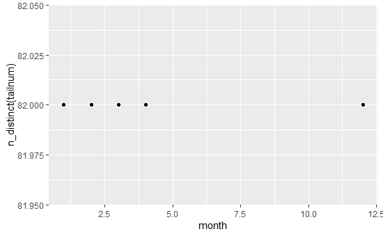